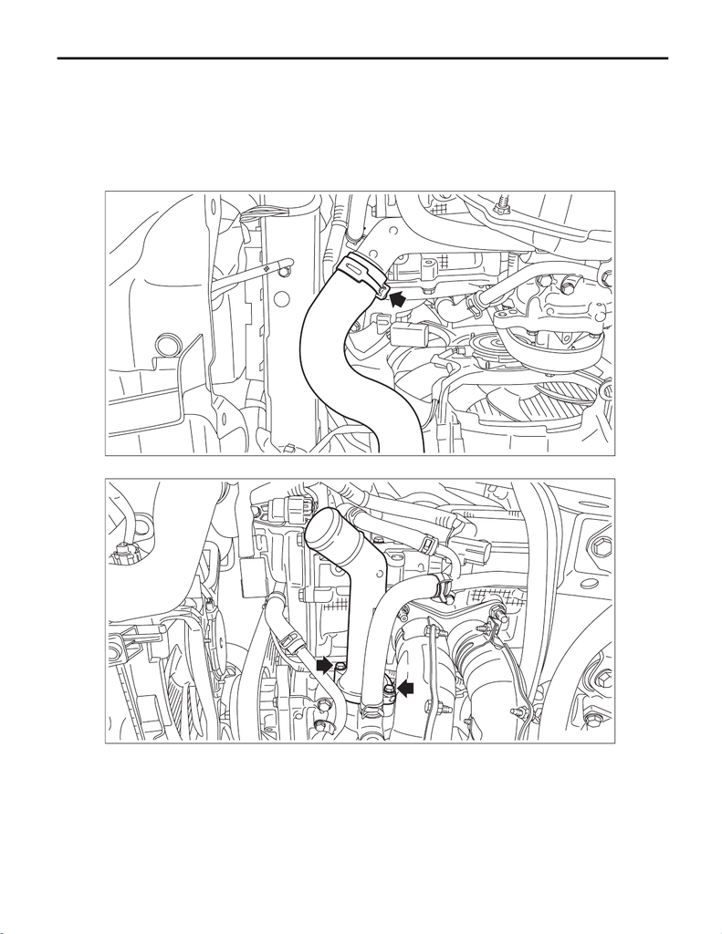

CO(w/o STI)-33

Thermostat

COOLING

6. Thermostat

A: REMOVAL

1) Disconnect the ground terminal from battery sensor. <Ref. to NT-5, BATTERY, NOTE, Note.>

2) Drain engine coolant. <Ref. to CO(w/o STI)-13, DRAINING OF ENGINE COOLANT, REPLACEMENT,

Engine Coolant.>

3) Remove the center exhaust pipe. <Ref. to EX(w/o STI)-35, REMOVAL, Center Exhaust Pipe.>

4) Disconnect the radiator outlet hose from thermostat cover.

5) Remove the thermostat cover, and then remove the thermostat.

6) Remove the gasket from thermostat.

CO-03215

CO-03216

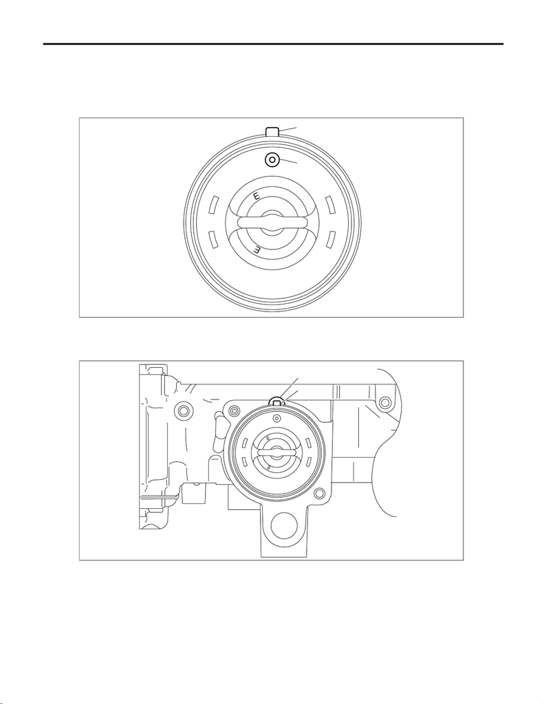

CO(w/o STI)-34

Thermostat

COOLING

B: INSTALLATION

1) Install a gasket to thermostat.

NOTE:

• Use a new gasket.

• Align the positions of the jig pin (a) and gasket ribs (b).

2) Install the thermostat and thermostat cover.

NOTE:

Align the oil pan upper cutout (a) with the position of the thermostat rib (b).

(b)

(a)

CO-03109

(a)

(b)

CO-03110

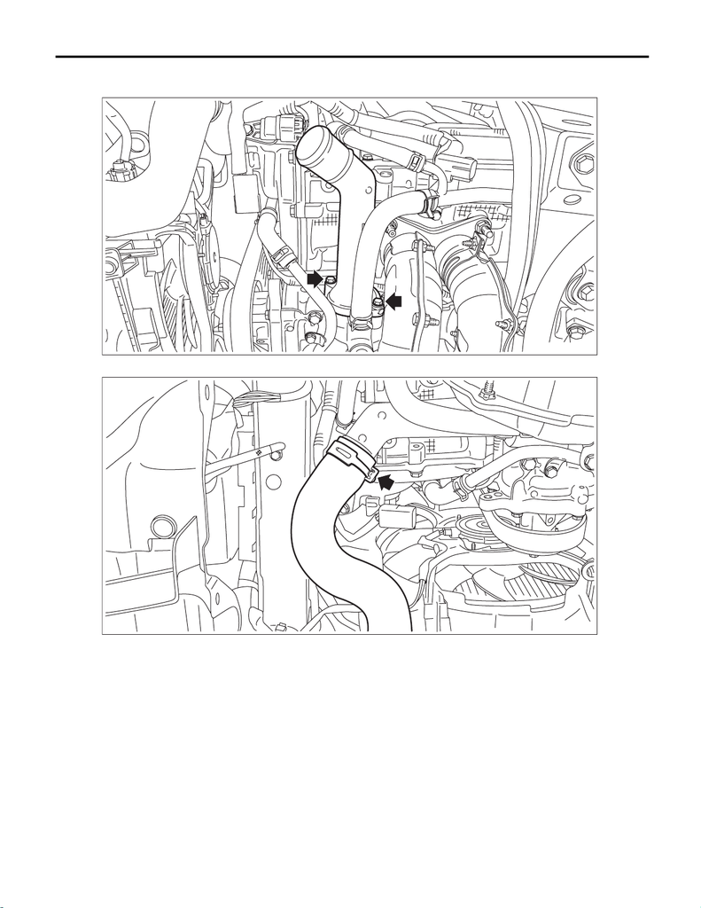

CO(w/o STI)-35

Thermostat

COOLING

Tightening torque:

6.4 N·m (0.7 kgf-m, 4.7 ft-lb)

3) Connect the radiator outlet hose to thermostat cover.

4) Install the center exhaust pipe. <Ref. to EX(w/o STI)-41, INSTALLATION, Center Exhaust Pipe.>

5) Install the under cover. <Ref. to EI-22, INSTALLATION, Front Under Cover.>

6) Lower the vehicle.

7) Connect the ground terminal to battery sensor. <Ref. to NT-5, BATTERY, NOTE, Note.>

8) Fill engine coolant. <Ref. to CO(w/o STI)-14, FILLING OF ENGINE COOLANT, REPLACEMENT, Engine

Coolant.>

CO-03216

CO-03215

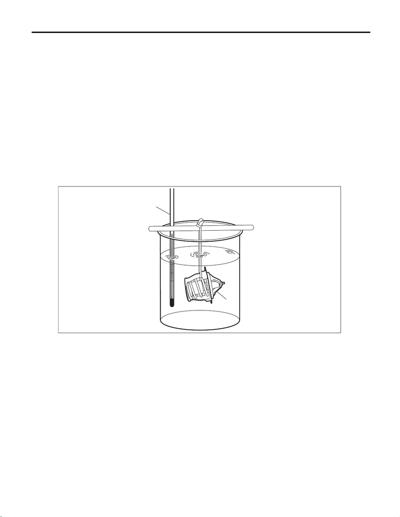

CO(w/o STI)-36

Thermostat

COOLING

C: INSPECTION

1) Check that the thermostat does not have deformation, cracks or damage.

2) Check that the thermostat valve closes completely at an ambient temperature.

3) Immerse the thermostat and a thermometer in water. Raise water temperature gradually, and check the

temperature and valve lift when the valve begins to open and when the valve is fully opened. Replace the

thermostat if faulty.

NOTE:

• During the test, agitate the water for even temperature distribution.

• Leave the thermostat in the boiling water for five minutes or more before measuring the valve lift.

• Hold the thermostat with a wire or the like to avoid contacting with container bottom.

Starting temperature to open:

86 — 90°C (187 — 194°F)

Full open temperature:

95°C (203°F)

Total valve lift:

8.0 mm (0.315 in) or more

(A) Thermometer (B) Thermostat

CO-02795

(A)

(B)